# STAT115 Homework 1

huzongyao

October 24, 2024

# 1 Part 0: Odyssey Signup

Please fill out the Odyssey survey on Canvas so we can create an account for you

# 2 Part I: Introduction to R

## 2.1 Problem 1: Installation

**Please install the following R/Bioconductor packages**

```r
if (!requireNamespace("BiocManager", quietly = TRUE))
    install.packages("BiocManager")
BiocManager::install()
BiocManager::install("sva")

install.packages(c("ggplot2", "dplyr", "tidyr", "HistData", "mvtnorm",
                   "reticulate"))
```

Please run this command (use `eval=TRUE`) to see if Bioconductor can work fine.

```r
BiocManager::valid()
```

```r
# these packages are needed for HW2
# affy and affyPLM are needed to read the microarray data and run RMA
library(sva) # for batch effect correction. Contains ComBat and sva.
library(ggplot2) # for plotting
library(dplyr) # for data manipulation
library(reticulate) # needed to run python in Rstudio
# these next two are not essential to this course
library(mvtnorm) # need this to simulate data from multivariate normal
library(HistData) # need this for data
```

## 2.2 Problem 2: Getting help

You can use the `mean()` function to compute the mean of a vector like so:

```r
x1 <- c(1:10, 50)
mean(x1)
```

```
## [1] 9.545455
```

However, this does not work if the vector contains NAs:

```r
x1_na <- c(1:10, 50, NA)
mean(x1_na)
```

```
## [1] NA
```

**Please use R documentation to find the mean after excluding NA’s (hint: `?mean`)**

```r
remove_na <- function(vec) {
    # Remove NaN values from the vector
    return(vec[!is.na(vec)])
}

# Example usage
x1_na <- c(1:10, 50, NA)
mean(x1_na)
```

```
## [1] NA
```

```r
remove_na(x1_na) %>% mean()
```

```
## [1] 9.545455
```

Grading: Grade on correctness.

- 0.5pt

# 3 Part II: Data Manipulation

## 3.1 Problem 3: Basic Selection

In this question, we will practice data manipulation using a dataset collected by Francis Galton in 1886 on the heights of parents and their children. This is a very famous dataset, and Galton used it to come up with regression and correlation.

The data is available as `GaltonFamilies` in the `HistData` package. Here, we load the data and show the first few rows. To find out more information about the dataset, use `?GaltonFamilies`.

```r
data(GaltonFamilies)
head(GaltonFamilies)
```

```
##   family father mother midparentHeight children childNum gender childHeight
## 1    001   78.5   67.0           75.43        4        1   male        73.2
## 2    001   78.5   67.0           75.43        4        2 female        69.2
## 3    001   78.5   67.0           75.43        4        3 female        69.0
## 4    001   78.5   67.0           75.43        4        4 female        69.0
## 5    002   75.5   66.5           73.66        4        1   male        73.5
## 6    002   75.5   66.5           73.66        4        2   male        72.5
```

1. **Please report the height of the 10th child in the dataset.**

```r
# report the height of the 10th child in the dataset.
GaltonFamilies$childHeight[10]
```

```
## [1] 68
```

2. **What is the breakdown of male and female children in the dataset?**

```r
# the breakdown of male and female children in the dataset
table(GaltonFamilies$gender)
```

```
##
## female   male
##    453    481
```

3. **How many observations (number of rows) are in Galton’s dataset? Please answer this question without consulting the R help.**

```r
# number of rows in Galton's dataset
nrow(GaltonFamilies)
```

```
## [1] 934
```

4. **What is the mean height for the 1st child in each family?**

```r
# the mean height for the 1st child in each family
GaltonFamilies %>%
    group_by(family) %>%
    summarise(meanHeight = mean(childHeight[1]))
```

```
## # A tibble: 205 × 2
##    family meanHeight
##    <fct>       <dbl>
##  1 001          73.2
##  2 002          73.5
##  3 003          71
##  4 004          70.5
##  5 005          72
##  6 006          69.5
##  7 007          76.5
##  8 008          70.5
##  9 009          66
## 10 010          65.5
## # ℹ 195 more rows
```

5. **Create a table showing the mean height for male and female children.**

```r
GaltonFamilies %>%
    group_by(gender) %>%
    summarise(meanHeight = mean(childHeight))
```

```
## # A tibble: 2 × 2
##   gender meanHeight
##   <fct>       <dbl>
## 1 female       64.1
## 2 male         69.2
```

6. **What was the average number of children each family had?**

```r
# the average number of children each family had
GaltonFamilies %>%
    group_by(family) %>%
    # count the number of children in each family
    summarise(nChildren = n()) %>%
    # create a new column with the mean number of children
    summarise(meanChildren = mean(nChildren))
```

```
## # A tibble: 1 × 1
##   meanChildren
##          <dbl>
## 1         4.56
```

7. **Convert the children’s heights from inches to centimeters and store it in a column called `childHeight_cm` in the `GaltonFamilies` dataset. Show the first few rows of this dataset.**

```r
GaltonFamilies$childHeight_cm <- GaltonFamilies$childHeight * 2.54
head(GaltonFamilies)
```

```
##   family father mother midparentHeight children childNum gender childHeight
## 1    001   78.5   67.0           75.43        4        1   male        73.2
## 2    001   78.5   67.0           75.43        4        2 female        69.2
## 3    001   78.5   67.0           75.43        4        3 female        69.0
## 4    001   78.5   67.0           75.43        4        4 female        69.0
## 5    002   75.5   66.5           73.66        4        1   male        73.5
## 6    002   75.5   66.5           73.66        4        2   male        72.5
##   childHeight_cm
## 1        185.928
## 2        175.768
## 3        175.260
## 4        175.260
## 5        186.690
## 6        184.150
```

## 3.2 Problem 4: Spurious Correlation

```r
# set seed for reproducibility
set.seed(1234)
N <- 25
ngroups <- 100000
sim_data <- data.frame(group = rep(1:ngroups, each = N),
                       X = rnorm(N * ngroups),
                       Y = rnorm(N * ngroups))
```

In the code above, we generate 10^{5} groups of 25 observations each. In each group, we have X and Y, where X and Y are independent normally distributed data and have 0 correlation.

1. **Find the correlation between X and Y for each group, and display the highest correlations.**

Hint: since the data is quite large and your code might take a few moments to run, you can test your code on a subset of the data first (e.g. you can take the first 100 groups like so):

```r
# the first 100 groups
sim_data_subset <- sim_data[sim_data$group <= 100, ]
# plot the sim_data_subset
# plot(sim_data_subset$X, sim_data_subset$Y)
# Find the correlation between X and Y for each group, and display the highest correlations.
sim_data_subset %>%
    # divide into 100 groups
    group_by(group) %>%
    # calculate the correlation between X and Y for each group
    summarise(correlation = cor(X, Y)) %>%
    # sort the correlations in descending order
    arrange(desc(correlation)) %>%
    head()
```

```
## # A tibble: 6 × 2
##   group correlation
##   <int>       <dbl>
## 1    71       0.445
## 2    48       0.374
## 3    72       0.367
## 4    61       0.343
## 5    58       0.325
## 6   100       0.310
```

In general, this is good practice whenever you have a large dataset: If you are writing new code and it takes a while to run on the whole dataset, get it to work on a subset first. By running on a subset, you can iterate faster.

However, please do run your final code on the whole dataset.

```r
sim_data %>%
    group_by(group) %>%
    summarise(correlation = cor(X, Y)) %>%
    arrange(desc(correlation)) %>%
    head()
```

```
## # A tibble: 6 × 2
##   group correlation
##   <int>       <dbl>
## 1 99655       0.801
## 2 98068       0.782
## 3 66510       0.746
## 4 46164       0.719
## 5 30063       0.719
## 6 63287       0.715
```

2. **The highest correlation is around 0.8. Can you explain why we see such a high correlation when X and Y are supposed to be independent and thus uncorrelated?**

> cherrypicked: To choose only the best

```r
sim_data %>%
    group_by(group) %>%
    summarise(correlation = cor(X, Y)) %>%
    # plot the histogram of the correlations
    # aes: aesthetic mapping
    ggplot(aes(x = correlation)) + geom_histogram(bins = 30)
```

[output not shown]

# 4 Part III: Plotting

## 4.1 Problem 5

**Show a plot of the data for the group that had the highest correlation you found in Problem 4.**

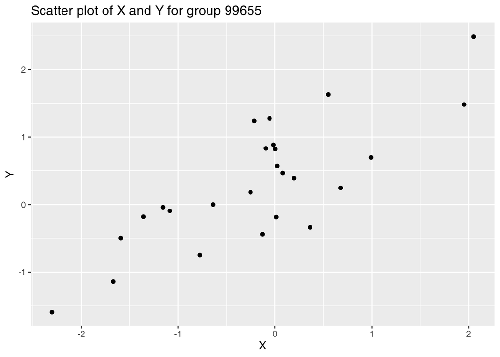

```r
# the data that had the highest correlation
sim_data %>%
    filter(group == 99655) %>%
    ggplot(aes(x = X, y = Y)) +
    geom_point() +
    ggtitle("Scatter plot of X and Y for group 99655")
```

Grading: 1pt.

## 4.2 Problem 6

We generate some sample data below. The data is numeric, and has 3 columns: X, Y, Z.

```r
N <- 100
# 定义协方差矩阵 (二维正态分布的相关性和方差)
Sigma <- matrix(c(1, 0.75, 0.75, 1), nrow = 2, ncol = 2) * 1.5
# 五组数据的均值坐标，这些均值构成了五个不同的正态分布中心
means <- list(c(11, 3), c(9, 5), c(7, 7), c(5, 9), c(3, 11))
# lapply: 对列表 means 中的每个元素执行操作，即对每个正态分布生成 N 个数据点
# rmvnorm: 生成多元正态分布数据
dat <- lapply(means, function(mu) rmvnorm(N, mu, Sigma))
# 将合并后的矩阵转换为数据框 (data.frame)
dat <- as.data.frame(Reduce(rbind, dat)) %>%
    # 为数据框新增一列 Z，用来标记每组数据点属于哪一个分布
    # seq_along(means): [1, 2, 3, 4, 5]
    # rep(sequence, each = N): 将 sequence 中的每个数重复 N 次，并将所有结果连接在一起
    # mutate(): dplyr 包中的一个函数，用于在数据框中添加或修改列
    mutate(Z = as.character(rep(seq_along(means), each = N)))
# 将数据框的列命名为 X、Y 和 Z (Z 是数据点的类别 1~5)
names(dat) <- c("X", "Y", "Z")
```

1. **Compute the overall correlation between X and Y.**

```r
dat %>%
    summarise(correlation = cor(X, Y))
```

```
##   correlation
## 1  -0.7362015
```

2. **Make a plot showing the relationship between X and Y. Comment on the correlation that you see.**

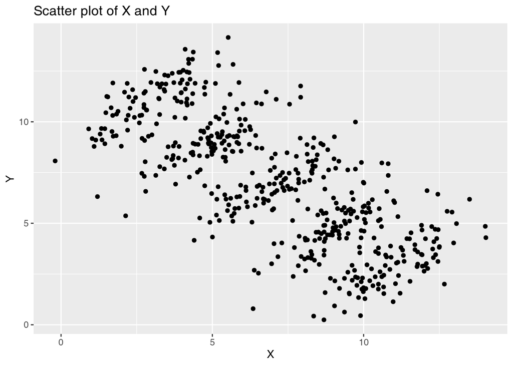

```r
# Make a plot showing the relationship between X and Y.
dat %>%
    ggplot(aes(x = X, y = Y)) +
    geom_point() +
    ggtitle("Scatter plot of X and Y")
```

> 根据图中的点的分布，可以很明显的看出 X 和 Y 是负相关的，但是这些点显然地分布在5组中。

The correlation between X and Y is negative.

3. **Compute the correlations between X and Y for each level of Z.**

```r
# Compute the correlations between X and Y for each level of Z.
dat %>%
    group_by(Z) %>%
    summarise(correlation = cor(X, Y))
```

```
## # A tibble: 5 × 2
##   Z     correlation
##   <chr>       <dbl>
## 1 1           0.743
## 2 2           0.756
## 3 3           0.772
## 4 4           0.785
## 5 5           0.730
```

4. **Make a plot showing the relationship between X and Y, but this time, color the points using the value of Z. Comment on the result, especially any differences between this plot and the previous plot.**

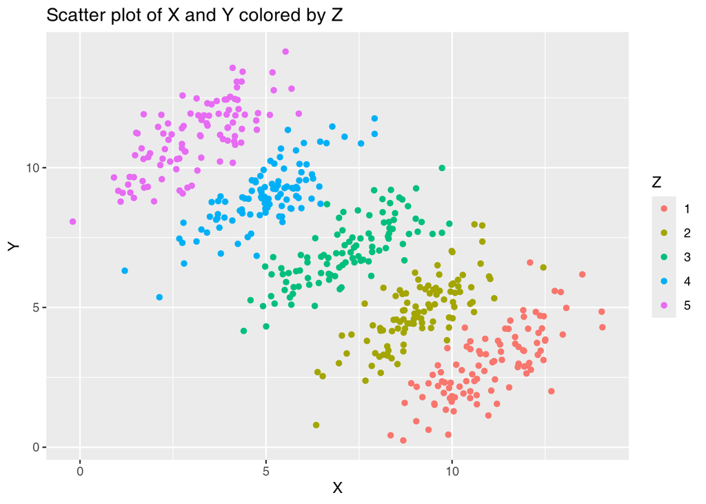

```r
dat %>%
    ggplot(aes(x = X, y = Y, color = Z)) +
    geom_point() +
    ggtitle("Scatter plot of X and Y colored by Z")
```

> 这是一个经典的辛普森悖论的例子，虽然一眼看上去 X 和 Y 呈负相关，但实际上当我们考虑 Z 变量时，在 Z 相同时，X 和 Y 是正相关的。

# 5 Part IV: Bash practices

## 5.1 Problem 7: Bash practices on Odyessy

Please answer the following question using bash commands and include those in your answer. Data are available at `/n/stat115/2020/HW1/public_MC3.maf`

Mutation Annotation Format ([MAF](https://docs.gdc.cancer.gov/Data/File_Formats/MAF_Format/)) is a tab-delimited text file with aggregated mutation information. MC3.maf `/n/stat115/2020/HW1/public_MC3.maf` is a curated list of [somatic mutation](https://www.britannica.com/science/somatic-mutation) occured in many patients with different types of cancers from TCGA (癌症基因组图谱).

> 由于GitHub上没有找到public_MC3.maf，我在mc3-2017中找到了相同的数据：[下载链接](https://api.gdc.cancer.gov/data/1c8cfe5f-e52d-41ba-94da-f15ea1337efc) mc3.v0.2.8.PUBLIC.maf 保存在 ${project}/assets/mc3.v0.2.8.PUBLIC.maf 由于源文件过大，无法使用正常的编辑器打开，我不得不使用 UltraEdit

Since a complete MAF file contains far more information than we need, in this problem we will focus on part of it.

```
Chromosome  Start_Position  Hugo_Symbol Variant_Classification
10  123810032   TACC2   Missense_Mutation
10  133967449   JAKMIP3 Silent
11  124489539   PANX3   Missense_Mutation
11  47380512    SPI1    Missense_Mutation
11  89868837    NAALAD2 Missense_Mutation
11  92570936    FAT3    Silent
12  107371855   MTERFD3 Missense_Mutation
12  108012011   BTBD11  Missense_Mutation
12  117768962   NOS1    5'Flank
```

In `/n/stats115/2020/HW1/MC3/public_MC3.maf`, `Chromosome` and `Start_Position` together specifies the genomics location where a location has happened. `Hogo_symbol` is the overlapping gene of that location, and `Variant_Classification` specifies how it influences downstream biological processes, e.g. transcription and translation.

Please include your bash commands and the full output from bash console with text answer to the questions.

1. How many lines are there in this file? How many times “KRAS” gene has emerged?

```bash
wc -l ../assets/mc3.v0.2.8.PUBLIC.maf # lines
grep -c KRAS ../assets/mc3.v0.2.8.PUBLIC.maf # KRAS
```

```
3600964 ../assets/mc3.v0.2.8.PUBLIC.maf
954
```

2. How many unique `Variant_Classification` are there in the MAF? Please count occurence of each type and sort them. Which one is the most frequent?

```bash
# head -n 1 ../assets/mc3.v0.2.8.PUBLIC.maf
# 由于我下载的数据比较全的原因，第9列是 Variant_Classification
cut -f 9 ../assets/mc3.v0.2.8.PUBLIC.maf | sort | uniq -c | sort -nr
```

```
1921979 Missense_Mutation
782687 Silent
282636 3'UTR
157232 Nonsense_Mutation
108104 Intron
87013 Frame_Shift_Del
81323 5'UTR
50617 Splice_Site
49540 RNA
27128 Frame_Shift_Ins
21060 3'Flank
15726 5'Flank
10254 In_Frame_Del
2723 Translation_Start_Site
2042 Nonstop_Mutation
 899 In_Frame_Ins
```

> Missense_Mutation is the most frequent type of mutation.
3. What are the top FIVE most frequent genes? Please provide the bash command and equivalent Python command. If you are a PI looking for a gene to investigate (you need to find a gene with potentially better biological significance), which gene out of the top 5 would you choose? Why?

```bash
# head -n 1 ../assets/mc3.v0.2.8.PUBLIC.maf
# 第1列是 Hugo_Symbol
cut -f 1 ../assets/mc3.v0.2.8.PUBLIC.maf | sort | uniq -c | sort -nr | head -n 5
```

```
15171 TTN
6875 MUC16
4601 TP53
3198 CSMD3
3102 SYNE1
```

Equivalent python command:

```python
import numpy as np
import pandas as pd
# read ../assets/mc3.v0.2.8.PUBLIC.maf
mc3_maf = pd.read_csv("../assets/mc3.v0.2.8.PUBLIC.maf", sep="\t")
# Lines in this file
print(mc3_maf.shape[0])
# count occurence of each unique Variant_Classification and sort them.
print(mc3_maf["Variant_Classification"].value_counts().sort_values(ascending=False))
# FIVE most frequent genes
print(mc3_maf["Hugo_Symbol"].value_counts().head(5))
```

```
3600963

Variant_Classification
Missense_Mutation         1921979
Silent                     782687
3'UTR                      282636
Nonsense_Mutation          157232
Intron                     108104
Frame_Shift_Del             87013
5'UTR                       81323
Splice_Site                 50617
RNA                         49540
Frame_Shift_Ins             27128
3'Flank                     21060
5'Flank                     15726
In_Frame_Del                10254
Translation_Start_Site       2723
Nonstop_Mutation             2042
In_Frame_Ins                  899
Name: count, dtype: int64

Hugo_Symbol
TTN      15171
MUC16     6875
TP53      4601
CSMD3     3198
SYNE1     3102
Name: count, dtype: int64
```

> 如果我是一个PI（Principal Investigator），我会选取 TP53 进行研究，因为经过查询我得知 TP53 是一个非常重要的抑癌基因。它被称为“基因组的守护者”，在细胞周期调控、DNA损伤修复和诱导细胞凋亡中起着至关重要的作用，也是很多现代抗癌药物的靶点。
4. Write a bash program that determines whether a user-input year ([YYYY]) is a leap year or not (all years that are multiples of four. If the year is centennial and not divisible by 400, then it is not a leap year). The user input can be either positional or interactive. Please include the content of your shell script here and test on 1900/2000/2002, does your code run as expected?

```bash
#!/bin/bash

# Function to check if the year is a leap year
is_leap_year() {
    local year=$1
    if (( year % 400 == 0 )); then
        echo "$year is a leap year."
    elif (( year % 100 == 0 )); then
        echo "$year is not a leap year."
    elif (( year % 4 == 0 )); then
        echo "$year is a leap year."
    else
        echo "$year is not a leap year."
    fi
}

# Main script logic
if [ -z "$1" ]; then
    # Interactive mode
    read -p "Enter a year: " year
    is_leap_year "$year"
else
    # Positional mode
    for year in "$@"; do
        is_leap_year "$year"
    done
fi

# Test by:
# ./leap_year.sh 1900 2000 2002
```

[output not shown]